# Integration

Spatial transcriptomics

Integration

Batch correction

In this lesson, we will evaluate whether batch effects are found in our dataset, which will inform our decision of whether to integrate or not. Additionally, this lesson will describe the methods behind some common methods for integration.

Author

Noor Sohail

Published

July 22, 2025

Keywords

PCA, UMAP, Harmony, CCA

Approximate time: 70 minutes

## Learning objectives

In this lesson, we will:

- Identify when integration is necessary
- Evaluate potential batch effects in our dataset
- Describe common integration algorithms

## Overview of lesson

When working with multiple samples, integration may **sometimes** be a necessary step. When there is a clear bias due to batch effect (date sequenced, replicate, etc.), it can be difficult to identify what is true biology and what is technical artifacts. Integration is a tool meant to align multiple datasets together. However, integration is **not always necessary**. The key is to assess the biology of your samples to evaluate whether integration is a necessary step for your analysis.

## What is integration?

Integration is the process by which uninteresting batch variables (date sequenced, kit used, platform, etc.) are accounted for to improve clustering of similar bins. The most common instance of this is when multiple samples, sequenced separately, are used for a single analysis. The aim is to **align the datasets** such that similar bins (cell states) are clustered together.

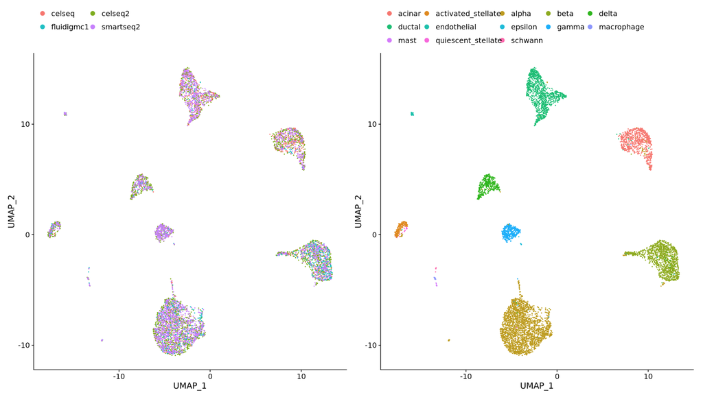

Figure 1: Example of integrating multiple scRNA-seq datasets generated with different library preparation methods.

**Why is it important that cells of the same cell type cluster together?**

We want to identify **cell types which are present in all samples/conditions/modalities** within our dataset, and therefore would like to observe a representation of cells from both samples/conditions/modalities in every cluster. This will enable more interpretable results downstream (i.e. DE analysis, ligand-receptor analysis, differential abundance analysis, etc.).